# Risk Factor Analysis

## Outcome Variable

**Outcome Variable:** stunted

## Predictor Variables

**Intervention Variable:** anywast06

**Adjustment Set:**

- arm
- sex
- W_mage
- meducyrs
- W_nrooms
- month
- brthmon
- delta_W_mage
- delta_meducyrs
- delta_W_nrooms
- delta_month
- delta_brthmon

## Stratifying Variables

The analysis was stratified on these variable(s):

- agecat
- studyid
- country

## Data Summary

| agecat | studyid | country | anywast06 | stunted | n_cell | n |
| --- | --- | --- | --- | --- | --- | --- |
| Birth | ki0047075b-MAL-ED | BANGLADESH | 0 | 0 | 163 | 255 |
| Birth | ki0047075b-MAL-ED | BANGLADESH | 0 | 1 | 35 | 255 |
| Birth | ki0047075b-MAL-ED | BANGLADESH | 1 | 0 | 47 | 255 |
| Birth | ki0047075b-MAL-ED | BANGLADESH | 1 | 1 | 10 | 255 |
| Birth | ki0047075b-MAL-ED | BRAZIL | 0 | 0 | 157 | 191 |
| Birth | ki0047075b-MAL-ED | BRAZIL | 0 | 1 | 21 | 191 |
| Birth | ki0047075b-MAL-ED | BRAZIL | 1 | 0 | 13 | 191 |
| Birth | ki0047075b-MAL-ED | BRAZIL | 1 | 1 | 0 | 191 |
| Birth | ki0047075b-MAL-ED | INDIA | 0 | 0 | 120 | 206 |
| Birth | ki0047075b-MAL-ED | INDIA | 0 | 1 | 24 | 206 |
| Birth | ki0047075b-MAL-ED | INDIA | 1 | 0 | 53 | 206 |
| Birth | ki0047075b-MAL-ED | INDIA | 1 | 1 | 9 | 206 |
| Birth | ki0047075b-MAL-ED | NEPAL | 0 | 0 | 128 | 173 |
| Birth | ki0047075b-MAL-ED | NEPAL | 0 | 1 | 13 | 173 |
| Birth | ki0047075b-MAL-ED | NEPAL | 1 | 0 | 27 | 173 |
| Birth | ki0047075b-MAL-ED | NEPAL | 1 | 1 | 5 | 173 |
| Birth | ki0047075b-MAL-ED | PERU | 0 | 0 | 245 | 286 |
| Birth | ki0047075b-MAL-ED | PERU | 0 | 1 | 30 | 286 |
| Birth | ki0047075b-MAL-ED | PERU | 1 | 0 | 8 | 286 |
| Birth | ki0047075b-MAL-ED | PERU | 1 | 1 | 3 | 286 |
| Birth | ki0047075b-MAL-ED | SOUTH AFRICA | 0 | 0 | 209 | 261 |
| Birth | ki0047075b-MAL-ED | SOUTH AFRICA | 0 | 1 | 21 | 261 |
| Birth | ki0047075b-MAL-ED | SOUTH AFRICA | 1 | 0 | 25 | 261 |
| Birth | ki0047075b-MAL-ED | SOUTH AFRICA | 1 | 1 | 6 | 261 |
| Birth | ki0047075b-MAL-ED | TANZANIA, UNITED REPUBLIC OF | 0 | 0 | 100 | 123 |
| Birth | ki0047075b-MAL-ED | TANZANIA, UNITED REPUBLIC OF | 0 | 1 | 17 | 123 |
| Birth | ki0047075b-MAL-ED | TANZANIA, UNITED REPUBLIC OF | 1 | 0 | 5 | 123 |
| Birth | ki0047075b-MAL-ED | TANZANIA, UNITED REPUBLIC OF | 1 | 1 | 1 | 123 |
| Birth | ki1000108-CMC-V-BCS-2002 | INDIA | 0 | 0 | 29 | 90 |
| Birth | ki1000108-CMC-V-BCS-2002 | INDIA | 0 | 1 | 7 | 90 |

[output cut: 170 more lines]

The following strata were considered:

- agecat: 24 months, studyid: ki0047075b-MAL-ED, country: BANGLADESH
- agecat: 24 months, studyid: ki0047075b-MAL-ED, country: BRAZIL
- agecat: 24 months, studyid: ki0047075b-MAL-ED, country: INDIA
- agecat: 24 months, studyid: ki0047075b-MAL-ED, country: NEPAL
- agecat: 24 months, studyid: ki0047075b-MAL-ED, country: PERU
- agecat: 24 months, studyid: ki0047075b-MAL-ED, country: SOUTH AFRICA
- agecat: 24 months, studyid: ki0047075b-MAL-ED, country: TANZANIA, UNITED REPUBLIC OF
- agecat: 24 months, studyid: ki1000108-CMC-V-BCS-2002, country: INDIA
- agecat: 24 months, studyid: ki1000108-IRC, country: INDIA
- agecat: 24 months, studyid: ki1017093b-PROVIDE, country: BANGLADESH
- agecat: 24 months, studyid: ki1066203-TanzaniaChild2, country: TANZANIA, UNITED REPUBLIC OF
- agecat: 24 months, studyid: ki1101329-Keneba, country: GAMBIA
- agecat: 24 months, studyid: ki1113344-GMS-Nepal, country: NEPAL
- agecat: 24 months, studyid: ki1114097-CMIN, country: BANGLADESH
- agecat: 24 months, studyid: ki1114097-CMIN, country: PERU
- agecat: 24 months, studyid: ki1114097-CONTENT, country: PERU
- agecat: 6 months, studyid: ki0047075b-MAL-ED, country: BANGLADESH
- agecat: 6 months, studyid: ki0047075b-MAL-ED, country: BRAZIL
- agecat: 6 months, studyid: ki0047075b-MAL-ED, country: INDIA
- agecat: 6 months, studyid: ki0047075b-MAL-ED, country: NEPAL
- agecat: 6 months, studyid: ki0047075b-MAL-ED, country: PERU
- agecat: 6 months, studyid: ki0047075b-MAL-ED, country: SOUTH AFRICA
- agecat: 6 months, studyid: ki0047075b-MAL-ED, country: TANZANIA, UNITED REPUBLIC OF
- agecat: 6 months, studyid: ki1000108-CMC-V-BCS-2002, country: INDIA
- agecat: 6 months, studyid: ki1000108-IRC, country: INDIA
- agecat: 6 months, studyid: ki1000109-EE, country: PAKISTAN
- agecat: 6 months, studyid: ki1000109-ResPak, country: PAKISTAN
- agecat: 6 months, studyid: ki1017093b-PROVIDE, country: BANGLADESH
- agecat: 6 months, studyid: ki1066203-TanzaniaChild2, country: TANZANIA, UNITED REPUBLIC OF
- agecat: 6 months, studyid: ki1101329-Keneba, country: GAMBIA
- agecat: 6 months, studyid: ki1112895-Guatemala BSC, country: GUATEMALA
- agecat: 6 months, studyid: ki1113344-GMS-Nepal, country: NEPAL
- agecat: 6 months, studyid: ki1114097-CMIN, country: BANGLADESH
- agecat: 6 months, studyid: ki1114097-CMIN, country: PERU
- agecat: 6 months, studyid: ki1114097-CONTENT, country: PERU
- agecat: Birth, studyid: ki0047075b-MAL-ED, country: BANGLADESH
- agecat: Birth, studyid: ki0047075b-MAL-ED, country: BRAZIL
- agecat: Birth, studyid: ki0047075b-MAL-ED, country: INDIA
- agecat: Birth, studyid: ki0047075b-MAL-ED, country: NEPAL
- agecat: Birth, studyid: ki0047075b-MAL-ED, country: PERU
- agecat: Birth, studyid: ki0047075b-MAL-ED, country: SOUTH AFRICA
- agecat: Birth, studyid: ki0047075b-MAL-ED, country: TANZANIA, UNITED REPUBLIC OF
- agecat: Birth, studyid: ki1000108-CMC-V-BCS-2002, country: INDIA
- agecat: Birth, studyid: ki1000108-IRC, country: INDIA
- agecat: Birth, studyid: ki1000109-EE, country: PAKISTAN
- agecat: Birth, studyid: ki1000109-ResPak, country: PAKISTAN
- agecat: Birth, studyid: ki1101329-Keneba, country: GAMBIA
- agecat: Birth, studyid: ki1114097-CMIN, country: BANGLADESH
- agecat: Birth, studyid: ki1114097-CMIN, country: PERU
- agecat: Birth, studyid: ki1114097-CONTENT, country: PERU

### Dropped Strata

Some strata were dropped due to rare outcomes:

- agecat: Birth, studyid: ki0047075b-MAL-ED, country: BRAZIL
- agecat: Birth, studyid: ki0047075b-MAL-ED, country: PERU
- agecat: Birth, studyid: ki0047075b-MAL-ED, country: TANZANIA, UNITED REPUBLIC OF
- agecat: Birth, studyid: ki1000109-EE, country: PAKISTAN
- agecat: Birth, studyid: ki1000109-ResPak, country: PAKISTAN
- agecat: Birth, studyid: ki1114097-CMIN, country: BANGLADESH
- agecat: Birth, studyid: ki1114097-CMIN, country: PERU
- agecat: Birth, studyid: ki1114097-CONTENT, country: PERU
- agecat: 6 months, studyid: ki0047075b-MAL-ED, country: BRAZIL
- agecat: 6 months, studyid: ki0047075b-MAL-ED, country: PERU
- agecat: 6 months, studyid: ki0047075b-MAL-ED, country: SOUTH AFRICA
- agecat: 6 months, studyid: ki0047075b-MAL-ED, country: TANZANIA, UNITED REPUBLIC OF
- agecat: 6 months, studyid: ki1112895-Guatemala BSC, country: GUATEMALA
- agecat: 6 months, studyid: ki1114097-CONTENT, country: PERU
- agecat: 24 months, studyid: ki0047075b-MAL-ED, country: BRAZIL
- agecat: 24 months, studyid: ki0047075b-MAL-ED, country: PERU
- agecat: 24 months, studyid: ki0047075b-MAL-ED, country: TANZANIA, UNITED REPUBLIC OF
- agecat: 24 months, studyid: ki1066203-TanzaniaChild2, country: TANZANIA, UNITED REPUBLIC OF
- agecat: 24 months, studyid: ki1114097-CONTENT, country: PERU

## Methods Detail

We’re interested in the causal parameters $E[Y_a]$ for all values of $a \in \mathcal{A}$. These parameters represent the mean outcome if, possibly contrary to fact, we intervened to set all units to have $A=a$. Under the randomization and positivity assumptions, these are identified by the statistical parameters $\psi_a=E_W[E_{Y|A,W}(Y|A=a,W)]$. In addition, we’re interested in the mean of $Y$, $E[Y]$ under no intervention (the observed mean). We will estimate these parameters by using SuperLearner to fit the relevant likelihood factors – $E_{Y|A,W}(Y|A=a,W)$ and $p(A=a|W)$, and then updating our likelihood fit using a joint TMLE.

For unadjusted analyses ($W=\{\}$), initial likelihoods were estimated using Lrnr_glm to estimate the simple $E(Y|A)$ and Lrnr_mean to estimate $p(A)$. For adjusted analyses, a small library containing Lrnr_glmnet, Lrnr_xgboost, and Lrnr_mean was used.

Having estimated these parameters, we will then use the delta method to estimate relative risks and attributable risks relative to a prespecified baseline level of $A$.

# Results Detail

## Results Plots

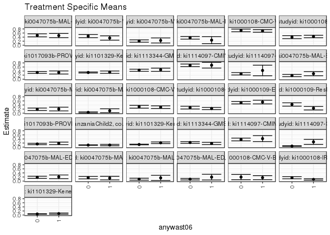

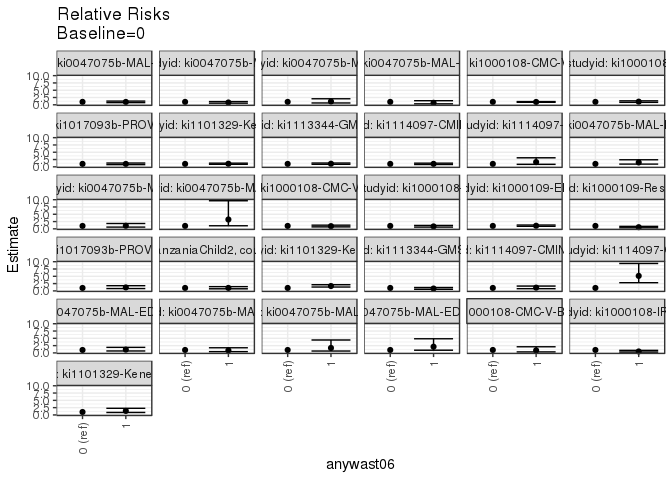

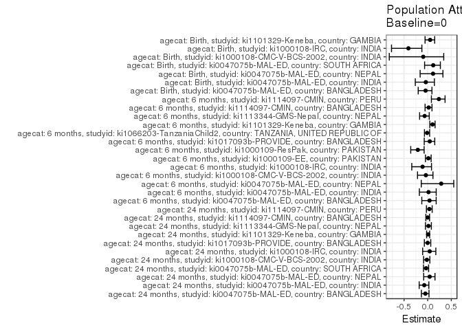

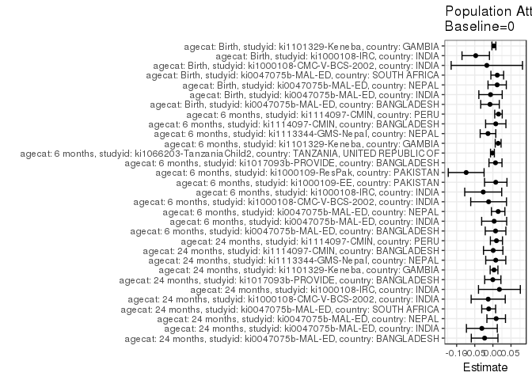

## Results Table

### Parameter: TSM

| agecat | studyid | country | intervention_level | baseline_level | estimate | ci_lower | ci_upper |
| --- | --- | --- | --- | --- | --- | --- | --- |
| Birth | ki0047075b-MAL-ED | BANGLADESH | 0 | NA | 0.1843933 | 0.1304543 | 0.2383323 |
| Birth | ki0047075b-MAL-ED | BANGLADESH | 1 | NA | 0.2074502 | 0.1173736 | 0.2975267 |
| Birth | ki0047075b-MAL-ED | INDIA | 0 | NA | 0.1666667 | 0.1056488 | 0.2276846 |
| Birth | ki0047075b-MAL-ED | INDIA | 1 | NA | 0.1451613 | 0.0572638 | 0.2330588 |
| Birth | ki0047075b-MAL-ED | NEPAL | 0 | NA | 0.0921986 | 0.0443075 | 0.1400897 |
| Birth | ki0047075b-MAL-ED | NEPAL | 1 | NA | 0.1562500 | 0.0300821 | 0.2824179 |
| Birth | ki0047075b-MAL-ED | SOUTH AFRICA | 0 | NA | 0.0913043 | 0.0540075 | 0.1286012 |
| Birth | ki0047075b-MAL-ED | SOUTH AFRICA | 1 | NA | 0.1935484 | 0.0542055 | 0.3328913 |
| Birth | ki1000108-CMC-V-BCS-2002 | INDIA | 0 | NA | 0.1944444 | 0.0644369 | 0.3244520 |
| Birth | ki1000108-CMC-V-BCS-2002 | INDIA | 1 | NA | 0.1666667 | 0.0667101 | 0.2666232 |
| Birth | ki1000108-IRC | INDIA | 0 | NA | 0.1633179 | 0.1083427 | 0.2182931 |
| Birth | ki1000108-IRC | INDIA | 1 | NA | 0.0808072 | 0.0454639 | 0.1161504 |
| Birth | ki1101329-Keneba | GAMBIA | 0 | NA | 0.0504534 | 0.0384893 | 0.0624174 |
| Birth | ki1101329-Keneba | GAMBIA | 1 | NA | 0.0697505 | 0.0392703 | 0.1002307 |
| 6 months | ki0047075b-MAL-ED | BANGLADESH | 0 | NA | 0.1793019 | 0.1246024 | 0.2340014 |
| 6 months | ki0047075b-MAL-ED | BANGLADESH | 1 | NA | 0.2695557 | 0.1696277 | 0.3694836 |
| 6 months | ki0047075b-MAL-ED | INDIA | 0 | NA | 0.1913580 | 0.1306545 | 0.2520616 |
| 6 months | ki0047075b-MAL-ED | INDIA | 1 | NA | 0.2027027 | 0.1109129 | 0.2944925 |
| 6 months | ki0047075b-MAL-ED | NEPAL | 0 | NA | 0.0362694 | 0.0098368 | 0.0627020 |
| 6 months | ki0047075b-MAL-ED | NEPAL | 1 | NA | 0.1162791 | 0.0202629 | 0.2122952 |
| 6 months | ki1000108-CMC-V-BCS-2002 | INDIA | 0 | NA | 0.3150274 | 0.2460265 | 0.3840282 |
| 6 months | ki1000108-CMC-V-BCS-2002 | INDIA | 1 | NA | 0.2925936 | 0.2283141 | 0.3568731 |
| 6 months | ki1000108-IRC | INDIA | 0 | NA | 0.2723439 | 0.2045391 | 0.3401487 |
| 6 months | ki1000108-IRC | INDIA | 1 | NA | 0.2275160 | 0.1747056 | 0.2803264 |
| 6 months | ki1000109-EE | PAKISTAN | 0 | NA | 0.5108927 | 0.4517456 | 0.5700398 |
| 6 months | ki1000109-EE | PAKISTAN | 1 | NA | 0.5446925 | 0.4527528 | 0.6366322 |
| 6 months | ki1000109-ResPak | PAKISTAN | 0 | NA | 0.4268611 | 0.3448937 | 0.5088284 |
| 6 months | ki1000109-ResPak | PAKISTAN | 1 | NA | 0.2426395 | 0.1562808 | 0.3289981 |
| 6 months | ki1017093b-PROVIDE | BANGLADESH | 0 | NA | 0.1540052 | 0.1200773 | 0.1879332 |
| 6 months | ki1017093b-PROVIDE | BANGLADESH | 1 | NA | 0.1824058 | 0.1204331 | 0.2443786 |
| 6 months | ki1066203-TanzaniaChild2 | TANZANIA, UNITED REPUBLIC OF | 0 | NA | 0.0982824 | 0.0842875 | 0.1122772 |
| 6 months | ki1066203-TanzaniaChild2 | TANZANIA, UNITED REPUBLIC OF | 1 | NA | 0.0999541 | 0.0671812 | 0.1327270 |
| 6 months | ki1101329-Keneba | GAMBIA | 0 | NA | 0.1274121 | 0.1116083 | 0.1432159 |
| 6 months | ki1101329-Keneba | GAMBIA | 1 | NA | 0.2123667 | 0.1703780 | 0.2543553 |
| 6 months | ki1113344-GMS-Nepal | NEPAL | 0 | NA | 0.2248709 | 0.1836006 | 0.2661413 |
| 6 months | ki1113344-GMS-Nepal | NEPAL | 1 | NA | 0.1796171 | 0.1226270 | 0.2366073 |
| 6 months | ki1114097-CMIN | BANGLADESH | 0 | NA | 0.3747314 | 0.3078664 | 0.4415963 |
| 6 months | ki1114097-CMIN | BANGLADESH | 1 | NA | 0.4158401 | 0.2682181 | 0.5634620 |
| 6 months | ki1114097-CMIN | PERU | 0 | NA | 0.0499006 | 0.0321777 | 0.0676236 |
| 6 months | ki1114097-CMIN | PERU | 1 | NA | 0.2563864 | 0.1311437 | 0.3816292 |
| 24 months | ki0047075b-MAL-ED | BANGLADESH | 0 | NA | 0.4850399 | 0.4102361 | 0.5598438 |
| 24 months | ki0047075b-MAL-ED | BANGLADESH | 1 | NA | 0.4757304 | 0.3728280 | 0.5786329 |
| 24 months | ki0047075b-MAL-ED | INDIA | 0 | NA | 0.4489282 | 0.3712691 | 0.5265874 |
| 24 months | ki0047075b-MAL-ED | INDIA | 1 | NA | 0.3544710 | 0.2492737 | 0.4596682 |
| 24 months | ki0047075b-MAL-ED | NEPAL | 0 | NA | 0.2057536 | 0.1478686 | 0.2636386 |
| 24 months | ki0047075b-MAL-ED | NEPAL | 1 | NA | 0.2343928 | 0.1105246 | 0.3582609 |
| 24 months | ki0047075b-MAL-ED | SOUTH AFRICA | 0 | NA | 0.3644860 | 0.2998672 | 0.4291047 |
| 24 months | ki0047075b-MAL-ED | SOUTH AFRICA | 1 | NA | 0.2500000 | 0.0763969 | 0.4236031 |
| 24 months | ki1000108-CMC-V-BCS-2002 | INDIA | 0 | NA | 0.7275464 | 0.6631453 | 0.7919475 |
| 24 months | ki1000108-CMC-V-BCS-2002 | INDIA | 1 | NA | 0.7036349 | 0.6411356 | 0.7661342 |
| 24 months | ki1000108-IRC | INDIA | 0 | NA | 0.3975904 | 0.3230503 | 0.4721304 |
| 24 months | ki1000108-IRC | INDIA | 1 | NA | 0.4279835 | 0.3656970 | 0.4902701 |
| 24 months | ki1017093b-PROVIDE | BANGLADESH | 0 | NA | 0.3294650 | 0.2850530 | 0.3738770 |
| 24 months | ki1017093b-PROVIDE | BANGLADESH | 1 | NA | 0.3287711 | 0.2525067 | 0.4050356 |
| 24 months | ki1101329-Keneba | GAMBIA | 0 | NA | 0.3286085 | 0.3030475 | 0.3541695 |
| 24 months | ki1101329-Keneba | GAMBIA | 1 | NA | 0.3447167 | 0.2877718 | 0.4016616 |
| 24 months | ki1113344-GMS-Nepal | NEPAL | 0 | NA | 0.4389337 | 0.3874677 | 0.4903997 |
| 24 months | ki1113344-GMS-Nepal | NEPAL | 1 | NA | 0.4640568 | 0.3857608 | 0.5423529 |
| 24 months | ki1114097-CMIN | BANGLADESH | 0 | NA | 0.6809217 | 0.6162373 | 0.7456061 |
| 24 months | ki1114097-CMIN | BANGLADESH | 1 | NA | 0.6869552 | 0.5466941 | 0.8272163 |
| 24 months | ki1114097-CMIN | PERU | 0 | NA | 0.2636364 | 0.2052898 | 0.3219830 |
| 24 months | ki1114097-CMIN | PERU | 1 | NA | 0.4285714 | 0.1687909 | 0.6883520 |

### Parameter: E(Y)

| agecat | studyid | country | intervention_level | baseline_level | estimate | ci_lower | ci_upper |
| --- | --- | --- | --- | --- | --- | --- | --- |
| Birth | ki0047075b-MAL-ED | BANGLADESH | NA | NA | 0.1764706 | 0.1295885 | 0.2233527 |
| Birth | ki0047075b-MAL-ED | INDIA | NA | NA | 0.1601942 | 0.1099849 | 0.2104035 |
| Birth | ki0047075b-MAL-ED | NEPAL | NA | NA | 0.1040462 | 0.0584174 | 0.1496751 |
| Birth | ki0047075b-MAL-ED | SOUTH AFRICA | NA | NA | 0.1034483 | 0.0664305 | 0.1404661 |
| Birth | ki1000108-CMC-V-BCS-2002 | INDIA | NA | NA | 0.1777778 | 0.0983474 | 0.2572081 |
| Birth | ki1000108-IRC | INDIA | NA | NA | 0.1159794 | 0.0840777 | 0.1478811 |
| Birth | ki1101329-Keneba | GAMBIA | NA | NA | 0.0532122 | 0.0420018 | 0.0644226 |
| 6 months | ki0047075b-MAL-ED | BANGLADESH | NA | NA | 0.1867220 | 0.1374205 | 0.2360234 |
| 6 months | ki0047075b-MAL-ED | INDIA | NA | NA | 0.1949153 | 0.1442678 | 0.2455627 |
| 6 months | ki0047075b-MAL-ED | NEPAL | NA | NA | 0.0508475 | 0.0227597 | 0.0789352 |
| 6 months | ki1000108-CMC-V-BCS-2002 | INDIA | NA | NA | 0.3032787 | 0.2561210 | 0.3504363 |
| 6 months | ki1000108-IRC | INDIA | NA | NA | 0.2457002 | 0.2038248 | 0.2875757 |
| 6 months | ki1000109-EE | PAKISTAN | NA | NA | 0.5188172 | 0.4679751 | 0.5696593 |
| 6 months | ki1000109-ResPak | PAKISTAN | NA | NA | 0.3531915 | 0.2919518 | 0.4144312 |
| 6 months | ki1017093b-PROVIDE | BANGLADESH | NA | NA | 0.1612350 | 0.1313580 | 0.1911120 |
| 6 months | ki1066203-TanzaniaChild2 | TANZANIA, UNITED REPUBLIC OF | NA | NA | 0.0970922 | 0.0842059 | 0.1099785 |
| 6 months | ki1101329-Keneba | GAMBIA | NA | NA | 0.1419543 | 0.1268686 | 0.1570400 |
| 6 months | ki1113344-GMS-Nepal | NEPAL | NA | NA | 0.2113677 | 0.1776128 | 0.2451225 |
| 6 months | ki1114097-CMIN | BANGLADESH | NA | NA | 0.3827160 | 0.3214780 | 0.4439541 |
| 6 months | ki1114097-CMIN | PERU | NA | NA | 0.0653907 | 0.0460250 | 0.0847565 |
| 24 months | ki0047075b-MAL-ED | BANGLADESH | NA | NA | 0.4622642 | 0.3949918 | 0.5295365 |
| 24 months | ki0047075b-MAL-ED | INDIA | NA | NA | 0.4185022 | 0.3541865 | 0.4828179 |
| 24 months | ki0047075b-MAL-ED | NEPAL | NA | NA | 0.2149123 | 0.1614774 | 0.2683472 |
| 24 months | ki0047075b-MAL-ED | SOUTH AFRICA | NA | NA | 0.3529412 | 0.2921001 | 0.4137823 |
| 24 months | ki1000108-CMC-V-BCS-2002 | INDIA | NA | NA | 0.7146739 | 0.6684741 | 0.7608737 |
| 24 months | ki1000108-IRC | INDIA | NA | NA | 0.4156479 | 0.3678270 | 0.4634689 |
| 24 months | ki1017093b-PROVIDE | BANGLADESH | NA | NA | 0.3292894 | 0.2909105 | 0.3676684 |
| 24 months | ki1101329-Keneba | GAMBIA | NA | NA | 0.3318414 | 0.3084975 | 0.3551853 |
| 24 months | ki1113344-GMS-Nepal | NEPAL | NA | NA | 0.4468938 | 0.4032281 | 0.4905594 |
| 24 months | ki1114097-CMIN | BANGLADESH | NA | NA | 0.6818182 | 0.6230135 | 0.7406228 |
| 24 months | ki1114097-CMIN | PERU | NA | NA | 0.2735043 | 0.2162683 | 0.3307402 |

### Parameter: RR

| agecat | studyid | country | intervention_level | baseline_level | estimate | ci_lower | ci_upper |
| --- | --- | --- | --- | --- | --- | --- | --- |
| Birth | ki0047075b-MAL-ED | BANGLADESH | 0 | 0 | 1.0000000 | 1.0000000 | 1.0000000 |
| Birth | ki0047075b-MAL-ED | BANGLADESH | 1 | 0 | 1.1250417 | 0.6642033 | 1.9056196 |
| Birth | ki0047075b-MAL-ED | INDIA | 0 | 0 | 1.0000000 | 1.0000000 | 1.0000000 |
| Birth | ki0047075b-MAL-ED | INDIA | 1 | 0 | 0.8709677 | 0.4292393 | 1.7672773 |
| Birth | ki0047075b-MAL-ED | NEPAL | 0 | 0 | 1.0000000 | 1.0000000 | 1.0000000 |
| Birth | ki0047075b-MAL-ED | NEPAL | 1 | 0 | 1.6947115 | 0.6488162 | 4.4265957 |
| Birth | ki0047075b-MAL-ED | SOUTH AFRICA | 0 | 0 | 1.0000000 | 1.0000000 | 1.0000000 |
| Birth | ki0047075b-MAL-ED | SOUTH AFRICA | 1 | 0 | 2.1198157 | 0.9264235 | 4.8505013 |
| Birth | ki1000108-CMC-V-BCS-2002 | INDIA | 0 | 0 | 1.0000000 | 1.0000000 | 1.0000000 |
| Birth | ki1000108-CMC-V-BCS-2002 | INDIA | 1 | 0 | 0.8571429 | 0.3491232 | 2.1043973 |
| Birth | ki1000108-IRC | INDIA | 0 | 0 | 1.0000000 | 1.0000000 | 1.0000000 |
| Birth | ki1000108-IRC | INDIA | 1 | 0 | 0.4947846 | 0.2847027 | 0.8598859 |
| Birth | ki1101329-Keneba | GAMBIA | 0 | 0 | 1.0000000 | 1.0000000 | 1.0000000 |
| Birth | ki1101329-Keneba | GAMBIA | 1 | 0 | 1.3824746 | 0.8409151 | 2.2728051 |
| 6 months | ki0047075b-MAL-ED | BANGLADESH | 0 | 0 | 1.0000000 | 1.0000000 | 1.0000000 |
| 6 months | ki0047075b-MAL-ED | BANGLADESH | 1 | 0 | 1.5033619 | 0.9309557 | 2.4277172 |
| 6 months | ki0047075b-MAL-ED | INDIA | 0 | 0 | 1.0000000 | 1.0000000 | 1.0000000 |
| 6 months | ki0047075b-MAL-ED | INDIA | 1 | 0 | 1.0592851 | 0.6093913 | 1.8413210 |
| 6 months | ki0047075b-MAL-ED | NEPAL | 0 | 0 | 1.0000000 | 1.0000000 | 1.0000000 |
| 6 months | ki0047075b-MAL-ED | NEPAL | 1 | 0 | 3.2059801 | 1.0657387 | 9.6443043 |
| 6 months | ki1000108-CMC-V-BCS-2002 | INDIA | 0 | 0 | 1.0000000 | 1.0000000 | 1.0000000 |
| 6 months | ki1000108-CMC-V-BCS-2002 | INDIA | 1 | 0 | 0.9287880 | 0.6814987 | 1.2658089 |
| 6 months | ki1000108-IRC | INDIA | 0 | 0 | 1.0000000 | 1.0000000 | 1.0000000 |
| 6 months | ki1000108-IRC | INDIA | 1 | 0 | 0.8353997 | 0.5947830 | 1.1733567 |
| 6 months | ki1000109-EE | PAKISTAN | 0 | 0 | 1.0000000 | 1.0000000 | 1.0000000 |
| 6 months | ki1000109-EE | PAKISTAN | 1 | 0 | 1.0661584 | 0.8690126 | 1.3080290 |
| 6 months | ki1000109-ResPak | PAKISTAN | 0 | 0 | 1.0000000 | 1.0000000 | 1.0000000 |
| 6 months | ki1000109-ResPak | PAKISTAN | 1 | 0 | 0.5684273 | 0.3794209 | 0.8515860 |
| 6 months | ki1017093b-PROVIDE | BANGLADESH | 0 | 0 | 1.0000000 | 1.0000000 | 1.0000000 |
| 6 months | ki1017093b-PROVIDE | BANGLADESH | 1 | 0 | 1.1844134 | 0.7904880 | 1.7746443 |
| 6 months | ki1066203-TanzaniaChild2 | TANZANIA, UNITED REPUBLIC OF | 0 | 0 | 1.0000000 | 1.0000000 | 1.0000000 |
| 6 months | ki1066203-TanzaniaChild2 | TANZANIA, UNITED REPUBLIC OF | 1 | 0 | 1.0170094 | 0.7114861 | 1.4537291 |
| 6 months | ki1101329-Keneba | GAMBIA | 0 | 0 | 1.0000000 | 1.0000000 | 1.0000000 |
| 6 months | ki1101329-Keneba | GAMBIA | 1 | 0 | 1.6667702 | 1.3201161 | 2.1044535 |
| 6 months | ki1113344-GMS-Nepal | NEPAL | 0 | 0 | 1.0000000 | 1.0000000 | 1.0000000 |
| 6 months | ki1113344-GMS-Nepal | NEPAL | 1 | 0 | 0.7987566 | 0.5541611 | 1.1513117 |
| 6 months | ki1114097-CMIN | BANGLADESH | 0 | 0 | 1.0000000 | 1.0000000 | 1.0000000 |
| 6 months | ki1114097-CMIN | BANGLADESH | 1 | 0 | 1.1097018 | 0.7467397 | 1.6490862 |
| 6 months | ki1114097-CMIN | PERU | 0 | 0 | 1.0000000 | 1.0000000 | 1.0000000 |
| 6 months | ki1114097-CMIN | PERU | 1 | 0 | 5.1379408 | 2.8085026 | 9.3994699 |
| 24 months | ki0047075b-MAL-ED | BANGLADESH | 0 | 0 | 1.0000000 | 1.0000000 | 1.0000000 |
| 24 months | ki0047075b-MAL-ED | BANGLADESH | 1 | 0 | 0.9808067 | 0.7533341 | 1.2769657 |
| 24 months | ki0047075b-MAL-ED | INDIA | 0 | 0 | 1.0000000 | 1.0000000 | 1.0000000 |
| 24 months | ki0047075b-MAL-ED | INDIA | 1 | 0 | 0.7895939 | 0.5618961 | 1.1095617 |
| 24 months | ki0047075b-MAL-ED | NEPAL | 0 | 0 | 1.0000000 | 1.0000000 | 1.0000000 |
| 24 months | ki0047075b-MAL-ED | NEPAL | 1 | 0 | 1.1391914 | 0.6265440 | 2.0712945 |
| 24 months | ki0047075b-MAL-ED | SOUTH AFRICA | 0 | 0 | 1.0000000 | 1.0000000 | 1.0000000 |
| 24 months | ki0047075b-MAL-ED | SOUTH AFRICA | 1 | 0 | 0.6858974 | 0.3349703 | 1.4044687 |
| 24 months | ki1000108-CMC-V-BCS-2002 | INDIA | 0 | 0 | 1.0000000 | 1.0000000 | 1.0000000 |
| 24 months | ki1000108-CMC-V-BCS-2002 | INDIA | 1 | 0 | 0.9671340 | 0.8539971 | 1.0952592 |
| 24 months | ki1000108-IRC | INDIA | 0 | 0 | 1.0000000 | 1.0000000 | 1.0000000 |
| 24 months | ki1000108-IRC | INDIA | 1 | 0 | 1.0764434 | 0.8490181 | 1.3647888 |
| 24 months | ki1017093b-PROVIDE | BANGLADESH | 0 | 0 | 1.0000000 | 1.0000000 | 1.0000000 |
| 24 months | ki1017093b-PROVIDE | BANGLADESH | 1 | 0 | 0.9978940 | 0.7630757 | 1.3049720 |
| 24 months | ki1101329-Keneba | GAMBIA | 0 | 0 | 1.0000000 | 1.0000000 | 1.0000000 |
| 24 months | ki1101329-Keneba | GAMBIA | 1 | 0 | 1.0490195 | 0.8739829 | 1.2591115 |
| 24 months | ki1113344-GMS-Nepal | NEPAL | 0 | 0 | 1.0000000 | 1.0000000 | 1.0000000 |
| 24 months | ki1113344-GMS-Nepal | NEPAL | 1 | 0 | 1.0572368 | 0.8627317 | 1.2955935 |
| 24 months | ki1114097-CMIN | BANGLADESH | 0 | 0 | 1.0000000 | 1.0000000 | 1.0000000 |
| 24 months | ki1114097-CMIN | BANGLADESH | 1 | 0 | 1.0088608 | 0.8054416 | 1.2636547 |
| 24 months | ki1114097-CMIN | PERU | 0 | 0 | 1.0000000 | 1.0000000 | 1.0000000 |
| 24 months | ki1114097-CMIN | PERU | 1 | 0 | 1.6256158 | 0.8526495 | 3.0993118 |

### Parameter: PAR

| agecat | studyid | country | intervention_level | baseline_level | estimate | ci_lower | ci_upper |
| --- | --- | --- | --- | --- | --- | --- | --- |
| Birth | ki0047075b-MAL-ED | BANGLADESH | 0 | NA | -0.0079227 | -0.0335031 | 0.0176576 |
| Birth | ki0047075b-MAL-ED | INDIA | 0 | NA | -0.0064725 | -0.0387049 | 0.0257599 |
| Birth | ki0047075b-MAL-ED | NEPAL | 0 | NA | 0.0118477 | -0.0133896 | 0.0370850 |
| Birth | ki0047075b-MAL-ED | SOUTH AFRICA | 0 | NA | 0.0121439 | -0.0054544 | 0.0297423 |
| Birth | ki1000108-CMC-V-BCS-2002 | INDIA | 0 | NA | -0.0166667 | -0.1151023 | 0.0817690 |
| Birth | ki1000108-IRC | INDIA | 0 | NA | -0.0473385 | -0.0851753 | -0.0095017 |
| Birth | ki1101329-Keneba | GAMBIA | 0 | NA | 0.0027588 | -0.0026865 | 0.0082042 |
| 6 months | ki0047075b-MAL-ED | BANGLADESH | 0 | NA | 0.0074201 | -0.0210083 | 0.0358485 |
| 6 months | ki0047075b-MAL-ED | INDIA | 0 | NA | 0.0035572 | -0.0309555 | 0.0380700 |
| 6 months | ki0047075b-MAL-ED | NEPAL | 0 | NA | 0.0145780 | -0.0039919 | 0.0331480 |
| 6 months | ki1000108-CMC-V-BCS-2002 | INDIA | 0 | NA | -0.0117487 | -0.0611279 | 0.0376305 |
| 6 months | ki1000108-IRC | INDIA | 0 | NA | -0.0266437 | -0.0776850 | 0.0243977 |
| 6 months | ki1000109-EE | PAKISTAN | 0 | NA | 0.0079245 | -0.0230081 | 0.0388571 |
| 6 months | ki1000109-ResPak | PAKISTAN | 0 | NA | -0.0736696 | -0.1231075 | -0.0242317 |
| 6 months | ki1017093b-PROVIDE | BANGLADESH | 0 | NA | 0.0072298 | -0.0107310 | 0.0251905 |
| 6 months | ki1066203-TanzaniaChild2 | TANZANIA, UNITED REPUBLIC OF | 0 | NA | -0.0011902 | -0.0065110 | 0.0041306 |
| 6 months | ki1101329-Keneba | GAMBIA | 0 | NA | 0.0145422 | 0.0064767 | 0.0226077 |
| 6 months | ki1113344-GMS-Nepal | NEPAL | 0 | NA | -0.0135033 | -0.0350334 | 0.0080269 |
| 6 months | ki1114097-CMIN | BANGLADESH | 0 | NA | 0.0079847 | -0.0200108 | 0.0359802 |
| 6 months | ki1114097-CMIN | PERU | 0 | NA | 0.0154901 | 0.0051403 | 0.0258399 |
| 24 months | ki0047075b-MAL-ED | BANGLADESH | 0 | NA | -0.0227758 | -0.0595508 | 0.0139993 |
| 24 months | ki0047075b-MAL-ED | INDIA | 0 | NA | -0.0304260 | -0.0730202 | 0.0121681 |
| 24 months | ki0047075b-MAL-ED | NEPAL | 0 | NA | 0.0091587 | -0.0164889 | 0.0348062 |
| 24 months | ki0047075b-MAL-ED | SOUTH AFRICA | 0 | NA | -0.0115448 | -0.0307331 | 0.0076435 |
| 24 months | ki1000108-CMC-V-BCS-2002 | INDIA | 0 | NA | -0.0128725 | -0.0599295 | 0.0341845 |
| 24 months | ki1000108-IRC | INDIA | 0 | NA | 0.0180576 | -0.0396735 | 0.0757886 |
| 24 months | ki1017093b-PROVIDE | BANGLADESH | 0 | NA | -0.0001756 | -0.0225065 | 0.0221554 |
| 24 months | ki1101329-Keneba | GAMBIA | 0 | NA | 0.0032329 | -0.0074515 | 0.0139174 |
| 24 months | ki1113344-GMS-Nepal | NEPAL | 0 | NA | 0.0079601 | -0.0197184 | 0.0356386 |
| 24 months | ki1114097-CMIN | BANGLADESH | 0 | NA | 0.0008965 | -0.0258681 | 0.0276610 |
| 24 months | ki1114097-CMIN | PERU | 0 | NA | 0.0098679 | -0.0068348 | 0.0265706 |

### Parameter: PAF

| agecat | studyid | country | intervention_level | baseline_level | estimate | ci_lower | ci_upper |
| --- | --- | --- | --- | --- | --- | --- | --- |
| Birth | ki0047075b-MAL-ED | BANGLADESH | 0 | NA | -0.0448954 | -0.2006242 | 0.0906342 |
| Birth | ki0047075b-MAL-ED | INDIA | 0 | NA | -0.0404040 | -0.2620941 | 0.1423456 |
| Birth | ki0047075b-MAL-ED | NEPAL | 0 | NA | 0.1138692 | -0.1597337 | 0.3229240 |
| Birth | ki0047075b-MAL-ED | SOUTH AFRICA | 0 | NA | 0.1173913 | -0.0651687 | 0.2686622 |
| Birth | ki1000108-CMC-V-BCS-2002 | INDIA | 0 | NA | -0.0937500 | -0.8131914 | 0.3402301 |
| Birth | ki1000108-IRC | INDIA | 0 | NA | -0.4081631 | -0.7659691 | -0.1228527 |
| Birth | ki1101329-Keneba | GAMBIA | 0 | NA | 0.0518461 | -0.0556458 | 0.1483926 |
| 6 months | ki0047075b-MAL-ED | BANGLADESH | 0 | NA | 0.0397387 | -0.1245850 | 0.1800515 |
| 6 months | ki0047075b-MAL-ED | INDIA | 0 | NA | 0.0182501 | -0.1757476 | 0.1802384 |
| 6 months | ki0047075b-MAL-ED | NEPAL | 0 | NA | 0.2867012 | -0.1360592 | 0.5521403 |
| 6 months | ki1000108-CMC-V-BCS-2002 | INDIA | 0 | NA | -0.0387388 | -0.2149915 | 0.1119457 |
| 6 months | ki1000108-IRC | INDIA | 0 | NA | -0.1084397 | -0.3366668 | 0.0808191 |
| 6 months | ki1000109-EE | PAKISTAN | 0 | NA | 0.0152742 | -0.0461871 | 0.0731248 |
| 6 months | ki1000109-ResPak | PAKISTAN | 0 | NA | -0.2085826 | -0.3587072 | -0.0750454 |
| 6 months | ki1017093b-PROVIDE | BANGLADESH | 0 | NA | 0.0448399 | -0.0731011 | 0.1498184 |
| 6 months | ki1066203-TanzaniaChild2 | TANZANIA, UNITED REPUBLIC OF | 0 | NA | -0.0122586 | -0.0685779 | 0.0410924 |
| 6 months | ki1101329-Keneba | GAMBIA | 0 | NA | 0.1024430 | 0.0447275 | 0.1566714 |
| 6 months | ki1113344-GMS-Nepal | NEPAL | 0 | NA | -0.0638851 | -0.1705692 | 0.0330759 |
| 6 months | ki1114097-CMIN | BANGLADESH | 0 | NA | 0.0208632 | -0.0551041 | 0.0913610 |
| 6 months | ki1114097-CMIN | PERU | 0 | NA | 0.2368856 | 0.0787078 | 0.3679057 |
| 24 months | ki0047075b-MAL-ED | BANGLADESH | 0 | NA | -0.0492700 | -0.1327045 | 0.0280186 |
| 24 months | ki0047075b-MAL-ED | INDIA | 0 | NA | -0.0727022 | -0.1799581 | 0.0248043 |
| 24 months | ki0047075b-MAL-ED | NEPAL | 0 | NA | 0.0426158 | -0.0843022 | 0.1546780 |
| 24 months | ki0047075b-MAL-ED | SOUTH AFRICA | 0 | NA | -0.0327103 | -0.0885726 | 0.0202854 |
| 24 months | ki1000108-CMC-V-BCS-2002 | INDIA | 0 | NA | -0.0180117 | -0.0861002 | 0.0458083 |
| 24 months | ki1000108-IRC | INDIA | 0 | NA | 0.0434444 | -0.1060775 | 0.1727536 |
| 24 months | ki1017093b-PROVIDE | BANGLADESH | 0 | NA | -0.0005332 | -0.0706997 | 0.0650351 |
| 24 months | ki1101329-Keneba | GAMBIA | 0 | NA | 0.0097424 | -0.0229837 | 0.0414216 |
| 24 months | ki1113344-GMS-Nepal | NEPAL | 0 | NA | 0.0178121 | -0.0461253 | 0.0778416 |
| 24 months | ki1114097-CMIN | BANGLADESH | 0 | NA | 0.0013148 | -0.0387221 | 0.0398085 |
| 24 months | ki1114097-CMIN | PERU | 0 | NA | 0.0360795 | -0.0268293 | 0.0951343 |